# Numerical Integration

STAT 778 — Lecture 4

Author

David Kepplinger

Published

February 11, 2026

Create a new project (including the corresponding Git repository on GitHub) and initialize renv or a python virtual environment (whichever system you will be using for the activities).

## Numerical integration

Consider the definite integral over a univariate function $g()$ which is continuous everywhere in $[a, b]$

$$\int_a^b g(x) \dx x.$$

The basic idea of numerical integration is to approximate the sum of many local polygons under the curve. Specifically, we partition the interval $[a, b]$ into $M$ subintervals, $[x_m, x_{m + 1}]$ for $m = 0:M-1$ with $x_0 = a$ and $x_M = b$. In each subinterval the integral can be approximated by
$$\int_{x_m}^{x_{m + 1}} g(x) \dx x \approx \sum_{k=0}^K A_{mk}\, g(x^*_{mk}).$$
with properly chosen $A_{mk}$ and $x^*_{mk} \in [x_m, x_{m + 1}]$. The parameter $K$ is equivalent with the *order* of the approximating function. The higher the order $K$, the more accurate the approximation will be. The integral can thus be written as

$$\int_a^b g(x) \dx x
= \sum_{m=1}^M \int_{x_m}^{x_{m + 1}} g(x) \dx x
= \sum_{m=1}^M \sum_{k=0}^K A_{mk}\, g(x^*_{mk}) + R_g(M,K),$$
where the residual $R_g(M) \to 0$ as $M \to \infty$. Numerical integration methods differ in how the gridpoints $x_m$, evaluation points $x^*_{mk}$ and constants $A_{mk}$ are chosen, and hence also in the magnitude of the residual term.

- **Riemann Rule ($K=0$):**approximate the function on each subinterval by a constant, namely $g(x^*_{m0})$, with $x^*_{m0} = x_m$. The appropriate constant is $A_{m0} = (x_{m + 1} - x_{m})$ and the approximation error is $O(1/n)$.
- **Trapezoidal Rule ($K=1$):** approximate the function on each subinterval by a line, with $x^*_{m0} = x_m, x^*_{m1} = x_{m+1}$. It can be easily derived that the constants are $A_{m0} = A_{m1} = (x_{m + 1} - x_{m}) / 2$. The approximation error is $O(n^{-2})$.
- **Simpson Rule ($K=2$):** approximate the function on each subinterval by a line, with $x^*_{m0} = x_m, x^*_{m1} = (x_m + x_{m+1}) / 2, x^*_{m2} = x_{m+1}$. The constants work out to be $A_{m0} = A_{m2} = (x_{m + 1} - x_{m}) / 6$ and $A_{m2} = 2 (A_{m0} + A_{m2})$. The approximation error is $O(n^{-4})$.

One can determine a general *k*-th order rule which is exact for polynomials of order *k* by the method of undetermined coefficients. See @Givens2013 for more details.

### (Adaptive) quadrature

The fixed node positions in the above methods makes them easy to derive and write down, but ineffective when approximating a complicated or poorly behaved function. When suitably choosing $M + 1$ nodes, $x_0 : x_{M}$ and corresponding weights $A_0 : A_M$, we can actually exactly integrate any polynomial of order $2(M+1)$.

**Gaussian quadrature** can be very efficient for integrals of the form $\int_a^b h(x) f(x) \dx x$, where $f$ is a non-negative function and $\int_a^b x^k f(x) \dx x < \infty$ for all $k > 0$. These conditions are reminiscent of a density function with finite moments. Hence Gaussian quadrature is a good tool to compute moments or normalizing constants. But Gaussian quadrature is also applicable when computing $\int_a^b g(x) \dx x$ by defining $h(x) = g(x) / f(x)$, for a suitably chosen density function $f$. The best node locations are roots of a set of orthogonal polynomials determined by $f$.

Let’s consider functions $h$ which are square-integrable w.r.t. $f$, i.e., $\int_a^b h(x)^2 f(x) \dx x < \infty$. This is denoted by $h \in \mathcal L^2_{f, [a,b]}$. For any two functions $g, h \in \mathcal L^2_{f, [a,b]}$, their inner product w.r.t. $f$ is
$$\langle g, h\rangle_{f, [a,b]} = \int_a^b h(x) g(x) f(x) \dx x.$$
If $<g, h>_{f, [a,b]} = 0$, then $f,g$ are said to be orthogonal with respect to $f$ on $[a,b]$.

For any $f$ that is nonnegative on $[a,b]$ there exists a sequence of polynomials $\{p_k(x)\}_{k=0}^\infty$ which are orthogonal w.r.t. $f$ over $[a,b]$. Without standardization this sequence is not unique. A common standardization is to set the leading coefficient of $p_k(x)$ to 1. It may also be beneficial to transform the interval $[a,b]$ to $[a^*,b^*]$, depending on $f$.

Many orthogonal polynomials can be summarized by a recurrence relation:

$$p_k(x) = (\alpha_k + \beta_k x) p_{k-1}(x) - \gamma_k p_{k-2}(x),$$
where $\alpha_k, \beta_k, \gamma_k$ vary with $k$ and $f$. The roots of such polynomial are all in an open interval $(a^*, b^*)$, with the endpoints possibly $\pm\infty$. In Gaussian quadrature, the roots of these polynomials are used as the nodes. See @Givens2013 for a way to derive the roots, but in practice you should be vary careful with doing that manually. Numerical imprecision can have a severe impact on the accuracy of the integration.

An issue with Gaussian quadrature is that increasing the number of nodes implies that the node positions will change, hence the function must be re-evaluated at all these nodes. There are ways alternative quadrature methods which avoid this issue, and hence they can compute the integral with successively more nodes without having to re-evaluate the function at all nodes. This is helpful to determine the number of nodes which give acceptable accuracy. Simply start with a small number of nodes and increase until the value of the integral does not change substantially anymore.

Gaussian quadrature with Hermitean polynomials are a simple way of integrating over the entire real line. In cases where the function $h$ vanishes near the extremes, truncation can also achieve a good approximation with controllable error.

Adaptive quadrature works by iteratively dividing the interval $[a, b]$ into smaller sub-intervals. In each sub-interval a quadrature approximation to the integral is computed. The iteration continues until an estimate of the error is below a prescribed threshold. This is done in the R function `integrate()` or the python function `scipi.integrate.quad()`.

Quadrature methods can be very efficient in computing integrals for smooth functions. These methods shown here converge in at least order of $O(n^{-2})$, and often even faster. They are, however, very difficult to extend to higher dimensions. Intuitively, these methods are placing node points over the entire domain, regardless of how much “mass” the function $f$ puts in these regions. In higher dimensions, this leads to a huge number of nodes in regions where $f$ is close to 0, which is computationally unfeasible.

### Monte Carlo integration

As discussed in the last lecture, if we have $N$ identical copies of the random variable $\mathcal X \sim F$ defined on $\Omega$, the law of large numbers gives us

$$\frac{1}{N} \sum_{j = 1}^N g(\mathcal X_j) \approx \E[g(\mathcal X)] = \int_\Omega g(\mathcal X) \;\mathrm{d} F(\mathcal X),$$
for $N$ large enough.

Therefore, if we can express our integral of interest as an expectation, we can use the LLN to approximate that integral. However, the strong law of large numbers guarantees a convergence rate of at most $O(n^{-1/2})$. Quadrature methods, on the other hand, achieve much better convergence rates.

The advantages of MC integration appear in higher dimensions, as the number of evaluation points for quadrature methods increases exponentially with the dimension! With MC integration, however, the convergence rate is independent of the dimension. Hence, particularly in high dimensions, the slow convergence rate of the SLLN is often compensated by the (relative) ease by which samples from $F$ can be generated. While with higher dimensions, generating from $F$ also becomes more challenging, there are tricks we can use that we will discuss at a later time.

## Example: Minimum Disparity/Divergence Estimators

In a usual parametric setup, we assume that the true population follows a stochastic law with parametric density $f_{\theta_0}$ and $\theta_0 \in \Theta$, i.e., $X_i \sim f_{\theta_0}$ and they are independent. Let us denote the family of distributions $\mathscr F := \{f_\theta\colon \theta \in \Theta\}$ such that $f_{\theta_0} \in \mathscr F$.

In simple maximum likelihood estimation settings, we seek to find the parameter $\hat\theta \in \Theta$, or equivalently the density $\hat f \in \mathscr F$, such that

$$\hat f_\text{MLE} := \argmin_{f \in \F} \sum_i \log f(x_i).$$

This is equivalent to finding the density in $\F$ which has the smallest “observed” Kullback–Leibler (KL) divergence with respect to the true density:

$$\hat f_\text{KL} = \argmin_{f \in \F} \hat{D}_\text{KL}(f_{\theta_0} \| f).$$
The population-level KL divergence is defined as
$$D_\text{KL}(p \| q) := \E_{x \sim p} \left[ \log \frac{p(x)}{q(x)} \right] = \int \log \left(\frac{p(x)}{q(x)} \right) p(x) \;\mathrm{d}x.$$

Show that $\hat f_\text{KL}$ is the same as $\hat f_\text{MLE}$.

You can use the fact that a good estimate (due to the LLN) for the population-level KL divergence is the empirical mean:
$$\hat{D}_\text{KL}(p \| q) := \frac{1}{n} \sum_i \log \left(\frac{p(x_i)}{q(x_i)} \right).$$

Hence, maximum likelihood estimation is equivalent to finding the parametric density that has smallest divergence to the observed data. While MLE has many advantages, particularly as it pertains to it’s easy computation and nice asymptotic properties, MLE and the KL-divergence also have downsides. An important disadvantage is that they are highly susceptible to model misspecification.

We will therefore try to implement a minimum divergence estimator (MDE) for a different divergence: the negative exponential disparity:

$$D_\text{NED}(p \| q) := \int \left( \exp\{-\delta(p, q, x) \} - 1 \right) q(x) \;\mathrm{d}x,$$
and $\delta(p, q)$ the Pearson residual
$$\delta(p, q, x) := \frac{p(x)}{q(x)} - 1.$$

Unfortunately, with the NED, we cannot simply use the LLN to get rid of the integral. Instead, it is common to use a kernel density estimate (KDE) for the observed data, $\hat g_n$, and find the model density most similar to it:

$$\hat \theta_\text{NED} := \argmin_{\theta \in \Theta} D_\text{NED}(\hat g_n \| f_\theta).$$

### Kernel Density Estimate

Given a sample of $n$ observations, $\{x_1, \dotsc, x_n\}$, the kernel density estimate with fixed bandwidth $h > 0$ and kernel function $K$ is given by
$$\hat g_n(y) := \frac{1}{n h} \sum_{i=1}^n K\left(\frac{|x_i - y|}{h} \right).$$
The following R function implements this simple KDE using the Epanechnikov kernel and naïve $O(n N)$ runtime complexity ($n$ observations, $N$ evaluation points).

```r
#' Simple KDE with Epanechnikov Kernel
#'
#' Evaluate the simple KDE at one or more locations.
#'
#' @param y numeric vector of evaluation points
#' @param x numeric vector of univariate observations
#' @param bw bandwidth for the kernel (default use [bw.nrd()]).
#' @return numeric vector with values of the evaluated KDE
kde_epan <- function (y, x, bw = 2 * bw.nrd(x)) {
  vapply(y, FUN.VALUE = numeric(1), FUN = \(pt) {
    d <- (x - pt) / bw
    ifelse(abs(d) < 1, 0.75 * (1 - d^2), 0) |>
      mean()
  }) / bw
}
```

It can be used like in the following code block.

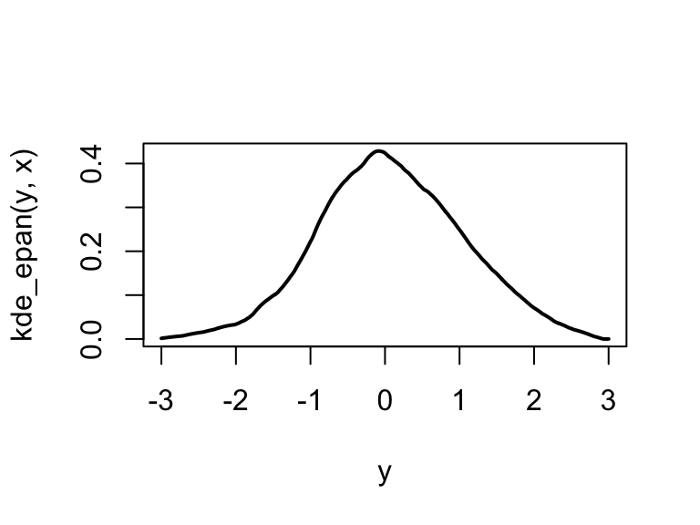

```r
set.seed(123)
x <- rnorm(100)
y <- seq(-3, 3, length.out = 1001)
plot(y, kde_epan(y, x), lwd = 2, type = 'l')
```

### Minimum Negative Exponential Disparity Estimator (MNEDE)

With this simple KDE and the off-the-shelve solver `optim()`, we can now try to estimate parameters for univariate models.

*Solution*.

Write a simple function that takes as input the observed data vector `x`, a model density function `model_dens`, the bandwidth `bw`, and the (theoretical) integration range `range`. It should return the evaluated NED, $D_\text{NED}(\hat g_n \| f_\theta)$. The model density function, `model_dens` is itself a function with signature `function (y) { ... }` which evaluates the model density at the requested points `y`. You can use the KDE implementation from above and off-the-shelve numeric integration routine, like `integrate()` in R.

Considering you name the function `ned_with_kde()`, we expect the following results

```r
set.seed(123)
x <- rbeta(100, shape1 = 4, shape2 = 3)
bw <- 2 * bw.nrd(x)
ned_with_kde(x, bw = bw, range = c(0, 1), model_dens = \(y) dbeta(y, shape1 = 4, shape2 = 3))
```

```
#> [1] 0.01113675
```

```r
ned_with_kde(x, bw = bw, range = c(0, 1), model_dens = \(y) dbeta(y, shape1 = 3, shape2 = 3))
```

```
#> [1] 0.0705756
```

```r
ned_with_kde(x, bw = bw, range = c(0, 1), model_dens = \(y) dbeta(y, shape1 = 4, shape2 = 4))
```

```
#> [1] 0.07842855
```

*N.B.: You will have to treat instances of `0/0` explicitly.*

*N.B.: Note that the R function `density()` is not suitable because it uses an approximation based on the fast Fourier transform (FFT).*

Now that you can evaluate the NED for any given model density, write another function that finds the Minimum NED Estimator (MNEDE) for the Beta model, i.e., where the model density is the Beta density with unknown shape parameters.

For this model family, the Nelder-Mead optimizer works very well (in R, you can use `optim(..., method = "Nelder-Mead")`), as long as you **optimize over the log-transformed parameters!**

Using the same test data as above, the procedure (here called `naive_mnede_beta()`) should return something like:

```r
set.seed(123)
x <- rbeta(100, shape1 = 4, shape2 = 3)
bw <- 2 * bw.nrd(x)
naive_mnede_beta(x, bw = bw)
```

```
#> $par
#> [1] 4.136090 3.210888
#>
#> $value
#> [1] 0.00938441
#>
#> $counts
#> function gradient
#>       65       NA
#>
#> $convergence
#> [1] 0
#>
#> $message
#> NULL
```

You will notice that the MNEDE implemented like this is very slow. Even for a simple problem as we’re dealing with here. The problem is that the integral must be evaluated at each step during the optimization. If we are using adaptive quadrature, the integrand, and therefore the KDE, is evaluated at different points each time. In this case, the bottleneck is the KDE, and if we could fix the integration points we would have to evaluate the KDE only once at these points for all optimization iterations.

Write a new MNEDE function using non-adaptive Gaussian quadrature. You first need to divide the integration domain into $M$ subintervals (say $M=100$). Then you can use the function `createIntegrationGrid(type = "GQU", dimension = 1, k = K)` from the `SparseGrid` R package to determine the weights $A_{mk}$ and nodes $x_{mk}$.

Your function should evaluate the KDE at the $K \times M$ nodes only once, and re-use those values during the optimization.